HW:1資料分析-糖尿病數據集

數據集描述:數據集由幾個醫學預測變量和一個目標變量組成，Outcome、預測變量包括患者的懷孕次數、BMI、胰島素水平、年齡等。\ 地區:所有患者都是至少 21 歲的皮馬印第安血統的女性\ 資料數:768\ 特徵變量:8

```python
import pandas as pd # 載入pandas 套件 命名引用名稱:pd
import numpy as np
import matplotlib.pyplot as plt
import seaborn as sns
import plotly.express as px
```

```python
rowdata = pd.read_csv("D:\Downloads\diabetes.csv") # 讀入csv檔，並把資料命名為 'rowdata'
rowdata.head(10) # show出前10筆資料
```

|  | Pregnancies | Glucose | BloodPressure | SkinThickness | Insulin | BMI | DiabetesPedigreeFunction | Age | Outcome |
| --- | --- | --- | --- | --- | --- | --- | --- | --- | --- |
| 0 | 6 | 148 | 72 | 35 | 0 | 33.6 | 0.627 | 50 | 1 |
| 1 | 1 | 85 | 66 | 29 | 0 | 26.6 | 0.351 | 31 | 0 |
| 2 | 8 | 183 | 64 | 0 | 0 | 23.3 | 0.672 | 32 | 1 |
| 3 | 1 | 89 | 66 | 23 | 94 | 28.1 | 0.167 | 21 | 0 |
| 4 | 0 | 137 | 40 | 35 | 168 | 43.1 | 2.288 | 33 | 1 |
| 5 | 5 | 116 | 74 | 0 | 0 | 25.6 | 0.201 | 30 | 0 |
| 6 | 3 | 78 | 50 | 32 | 88 | 31.0 | 0.248 | 26 | 1 |
| 7 | 10 | 115 | 0 | 0 | 0 | 35.3 | 0.134 | 29 | 0 |
| 8 | 2 | 197 | 70 | 45 | 543 | 30.5 | 0.158 | 53 | 1 |
| 9 | 8 | 125 | 96 | 0 | 0 | 0.0 | 0.232 | 54 | 1 |

```python
rowdata.dtypes #查看資料集內的特徵資料型態
```

```
Pregnancies                   int64
Glucose                       int64
BloodPressure                 int64
SkinThickness                 int64
Insulin                       int64
BMI                         float64
DiabetesPedigreeFunction    float64
Age                           int64
Outcome                       int64
dtype: object
```

````python
rowdata['Outcome'].value_counts() #使用```pandas```套件觀察['Outcome']欄位分布
````

```
0    500
1    268
Name: Outcome, dtype: int64
```

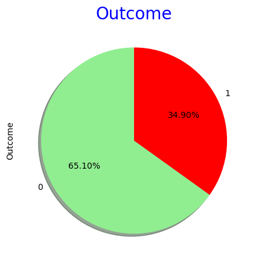

```python
colors = ["lightgreen", "red"]
rowdata["Outcome"].value_counts().plot(
    kind="pie", #圖形類別: 圓餅圖
    shadow=True,#圓餅圖陰影
    startangle=90,#圓餅圖角度
    figsize=(5, 5),#圖形大小
    autopct="%1.2f%%",
    colors=colors,
)
plt.title("Outcome", fontsize=20, color="blue")
```

```python
#紀錄資料型態不是object的數量(這裡裡的資料全為int或float)
num_cols = [col for col in rowdata.columns if rowdata[col].dtype != 'object']
```

由下圖可發現，Glucose、BloodPressure、SkinThickness、BMI的數據資料大多呈負偏態，但卻出現不少值為0的資料，由此可發現，這些資料可能是有問題的，之後須考慮將這些離群值刪去

[output not shown]

[output cut: 60 more lines]

[output not shown]

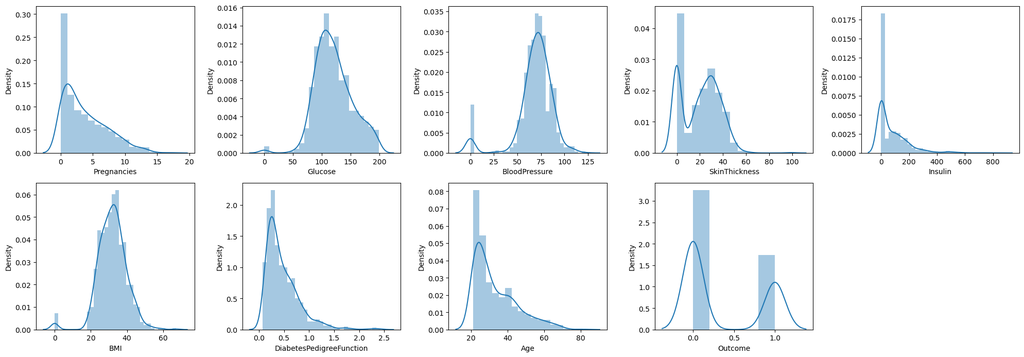

```python
plt.figure(figsize = (20,10))
plot_number = 1

for column in num_cols:
    if plot_number <= 14:
        ax = plt.subplot(3, 5, plot_number)
        sns.distplot(rowdata[column])
        plt.xlabel(column)

    plot_number += 1

plt.tight_layout()
plt.show()
```

使用提琴圖及分布估計圖觀察資料

透過不同特徵變量與有無糖尿病來進行特徵分析

```python
def violin(col):
    fig = px.violin(rowdata, y=col, x="Outcome", color="Outcome", box=True, template = 'plotly_dark')
    return fig.show()

def kde(col):
    grid = sns.FacetGrid(rowdata, hue="Outcome", height = 6, aspect=2)
    grid.map(sns.kdeplot, col)
    grid.add_legend()
```

```python
violin('Pregnancies')
violin('Glucose')
violin('BloodPressure')
violin('SkinThickness')
violin('Insulin')
violin('BMI')
violin('DiabetesPedigreeFunction')
violin('Age')
```

[interactive chart not shown]

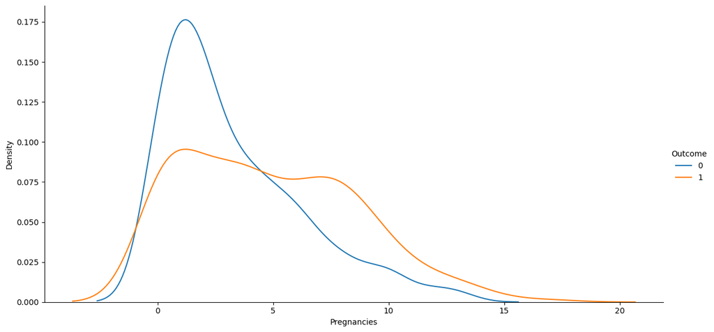

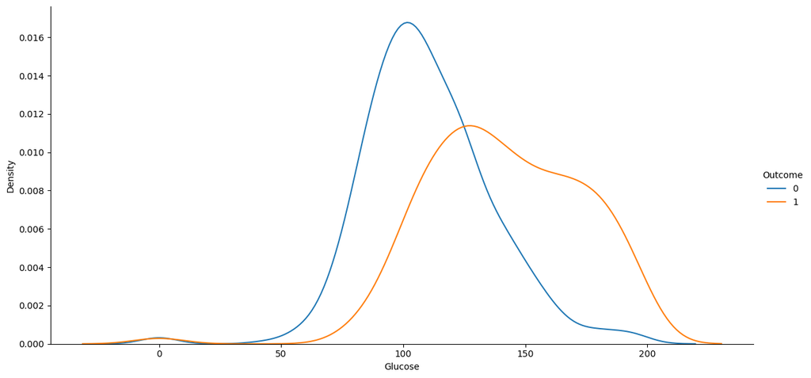

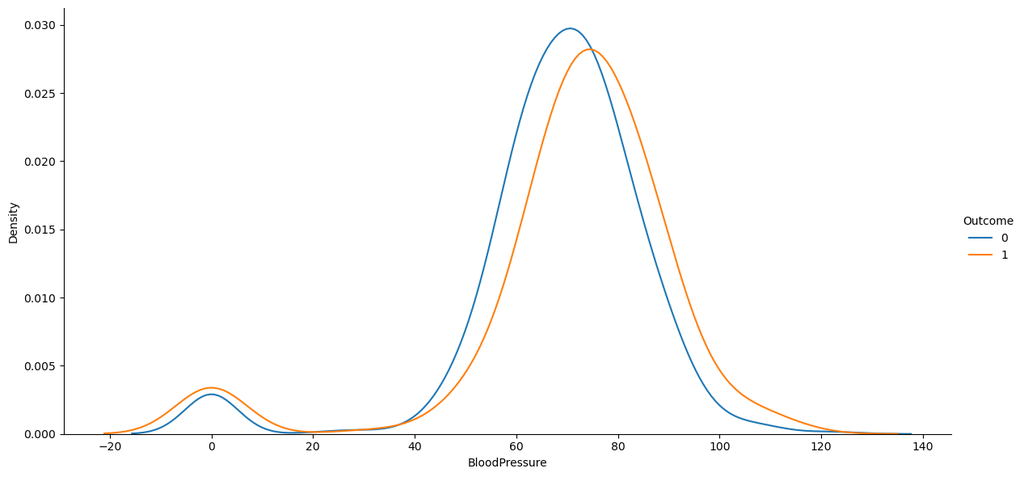

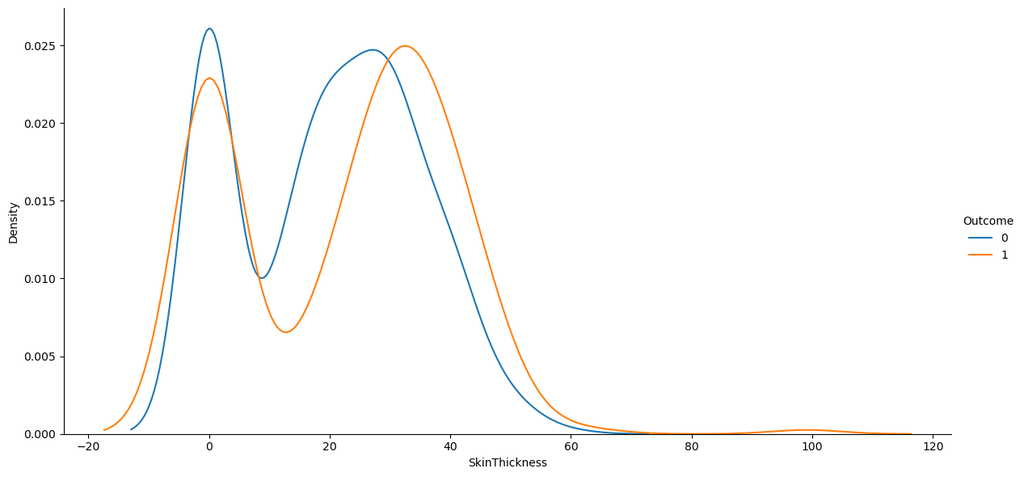

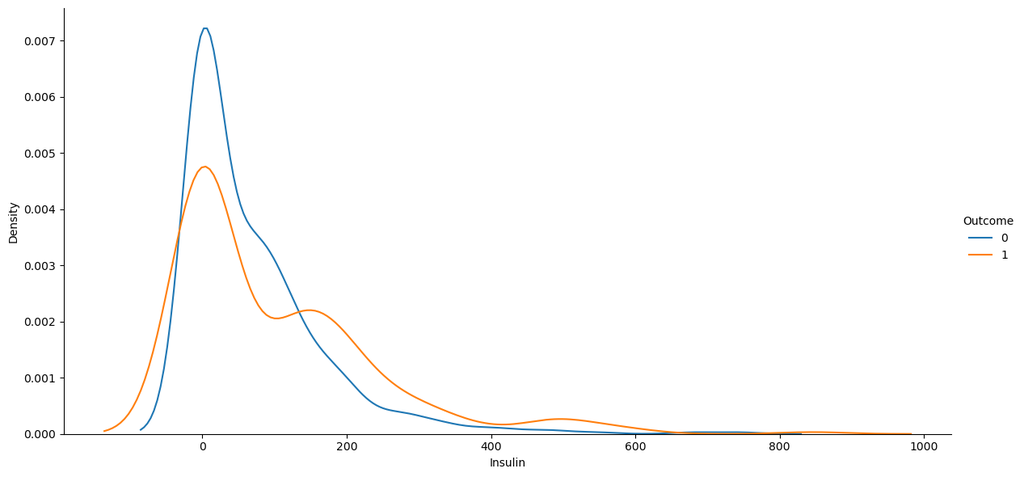

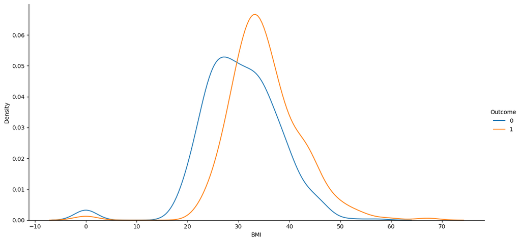

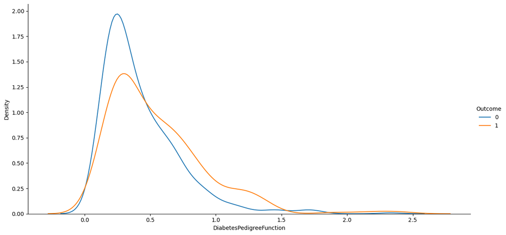

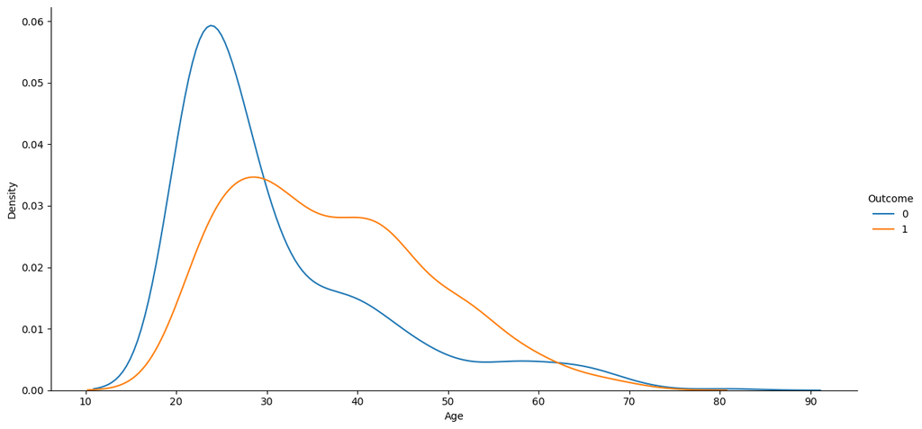

```python
kde('Pregnancies')
kde('Glucose')
kde('BloodPressure')
kde('SkinThickness')
kde('Insulin')
kde('BMI')
kde('DiabetesPedigreeFunction')
kde('Age')
```

特徵工程

```python
rowdata.isnull().sum(axis=0)#檢查缺失值數量
```

```
Pregnancies                 0
Glucose                     0
BloodPressure               0
SkinThickness               0
Insulin                     0
BMI                         0
DiabetesPedigreeFunction    0
Age                         0
Outcome                     0
dtype: int64
```

無缺失值，不用移除缺失值。

透過特徵分析決定進行離群值刪去以下共刪去四點 1.Glucose 2.BloodPressure 3.SkinThickness 4.BMI 考慮到這四點出現實際資料為0可能性較低，因此決定將離群值刪去

```python
rowdata["Glucose"].value_counts() #統計"Glucose"中有多少0
```

```
99     17
100    17
111    14
129    14
125    14
       ..
191     1
177     1
44      1
62      1
190     1
Name: Glucose, Length: 136, dtype: int64
```

```python
rowdata["BloodPressure"].value_counts() #統計"BloodPressure"中有多少0
```

```
70     57
74     52
78     45
68     45
72     44
64     43
80     40
76     39
60     37
0      35
62     34
66     30
82     30
88     25
84     23
```

[output cut: 33 more lines]

```python
rowdata["BMI"].value_counts()#統計"BMI"中有多少0
```

```
32.0    13
31.6    12
31.2    12
0.0     11
32.4    10
        ..
36.7     1
41.8     1
42.6     1
42.8     1
46.3     1
Name: BMI, Length: 248, dtype: int64
```

```python
rowdata[(rowdata. Glucose == 0)].index.tolist()#找出0的索引
```

```
[75, 182, 342, 349, 502]
```

```python
rowdata[(rowdata.BloodPressure == 0)].index.tolist()#找出0的索引
```

```
[7,
 15,
 49,
 60,
 78,
 81,
 172,
 193,
 222,
 261,
 266,
 269,
 300,
 332,
 336,
 347,
 357,
 426,
 430,
 435,
 453,
 468,
 484,
 494,
 522,
 533,
 535,
 589,
 601,
 604,
 619,
 643,
 697,
 703,
 706]
```

```python
rowdata[(rowdata.BMI == 0)].index.tolist()#找出0的索引
```

```
[9, 49, 60, 81, 145, 371, 426, 494, 522, 684, 706]
```

```python
rowdata = rowdata.drop(index = rowdata[(rowdata.Glucose == 0)].index.tolist())
#使用drop函数以及index参数删除所在的行
```

```python
rowdata = rowdata.drop(index = rowdata[(rowdata.BloodPressure == 0)].index.tolist())
#使用drop函数以及index参数删除所在的行
```

```python
rowdata =  rowdata.drop(index = rowdata[(rowdata.BMI == 0)].index.tolist())
#使用drop函数以及index参数删除所在的行
```

```python
rowdata =  rowdata.drop(index = rowdata[(rowdata.SkinThickness == 0)].index.tolist())
#使用drop函数以及index参数删除所在的行
```

```python
rowdata.info() #查看數據
```

```
<class 'pandas.core.frame.DataFrame'>
Int64Index: 532 entries, 0 to 767
Data columns (total 9 columns):
 #   Column                    Non-Null Count  Dtype
---  ------                    --------------  -----
 0   Pregnancies               532 non-null    int64
 1   Glucose                   532 non-null    int64
 2   BloodPressure             532 non-null    int64
 3   SkinThickness             532 non-null    int64
 4   Insulin                   532 non-null    int64
 5   BMI                       532 non-null    float64
 6   DiabetesPedigreeFunction  532 non-null    float64
 7   Age                       532 non-null    int64
 8   Outcome                   532 non-null    int64
dtypes: float64(2), int64(7)
memory usage: 41.6 KB
```

參考 https://www.jb51.net/article/246310.htm 中刪除資料中值為0的方法

```python
data = rowdata
```

```python
print(data)
```

```
     Pregnancies  Glucose  BloodPressure  SkinThickness  Insulin   BMI  \
0              6      148             72             35        0  33.6
1              1       85             66             29        0  26.6
3              1       89             66             23       94  28.1
4              0      137             40             35      168  43.1
6              3       78             50             32       88  31.0
..           ...      ...            ...            ...      ...   ...
761            9      170             74             31        0  44.0
763           10      101             76             48      180  32.9
764            2      122             70             27        0  36.8
765            5      121             72             23      112  26.2
767            1       93             70             31        0  30.4

     DiabetesPedigreeFunction  Age  Outcome
0                       0.627   50        1
1                       0.351   31        0
3                       0.167   21        0
4                       2.288   33        1
6                       0.248   26        1
..                        ...  ...      ...
761                     0.403   43        1
763                     0.171   63        0
764                     0.340   27        0
765                     0.245   30        0
767                     0.315   23        0

[532 rows x 9 columns]
```

```python
# 將移除Outcome(預測目標)的剩餘欄位命名為 clear_data
clear_data = data.drop(['Outcome'],axis=1)

# 將Outcome(預測目標)欄位命名為 label
label = data['Outcome']
```

```python
clear_data.head(5)#列出前5筆確認有沒有問題
```

|  | Pregnancies | Glucose | BloodPressure | SkinThickness | Insulin | BMI | DiabetesPedigreeFunction | Age |
| --- | --- | --- | --- | --- | --- | --- | --- | --- |
| 0 | 6 | 148 | 72 | 35 | 0 | 33.6 | 0.627 | 50 |
| 1 | 1 | 85 | 66 | 29 | 0 | 26.6 | 0.351 | 31 |
| 3 | 1 | 89 | 66 | 23 | 94 | 28.1 | 0.167 | 21 |
| 4 | 0 | 137 | 40 | 35 | 168 | 43.1 | 2.288 | 33 |
| 6 | 3 | 78 | 50 | 32 | 88 | 31.0 | 0.248 | 26 |

```python
clear_data.dtypes# 查看整份資料所有欄位資料型態
```

```
Pregnancies                   int64
Glucose                       int64
BloodPressure                 int64
SkinThickness                 int64
Insulin                       int64
BMI                         float64
DiabetesPedigreeFunction    float64
Age                           int64
dtype: object
```

資料型態完整，因此不須額外校正

模型開發

```python
x_features = clear_data.iloc[:,:] #從清整後的training data拆出features
y_label =label#從清整後的training data拆出label
x_features
```

|  | Pregnancies | Glucose | BloodPressure | SkinThickness | Insulin | BMI | DiabetesPedigreeFunction | Age |
| --- | --- | --- | --- | --- | --- | --- | --- | --- |
| 0 | 6 | 148 | 72 | 35 | 0 | 33.6 | 0.627 | 50 |
| 1 | 1 | 85 | 66 | 29 | 0 | 26.6 | 0.351 | 31 |
| 3 | 1 | 89 | 66 | 23 | 94 | 28.1 | 0.167 | 21 |
| 4 | 0 | 137 | 40 | 35 | 168 | 43.1 | 2.288 | 33 |
| 6 | 3 | 78 | 50 | 32 | 88 | 31.0 | 0.248 | 26 |
| ... | ... | ... | ... | ... | ... | ... | ... | ... |
| 761 | 9 | 170 | 74 | 31 | 0 | 44.0 | 0.403 | 43 |
| 763 | 10 | 101 | 76 | 48 | 180 | 32.9 | 0.171 | 63 |
| 764 | 2 | 122 | 70 | 27 | 0 | 36.8 | 0.340 | 27 |
| 765 | 5 | 121 | 72 | 23 | 112 | 26.2 | 0.245 | 30 |
| 767 | 1 | 93 | 70 | 31 | 0 | 30.4 | 0.315 | 23 |

532 rows × 8 columns

```python
y_label=np.array(y_label)
```

1.切分資料集 2.選擇模型

```python
from sklearn.model_selection import KFold #k-fold函式
kf = KFold(n_splits = 5, shuffle=True, random_state=42)#定義k折交叉驗證
from sklearn.linear_model import LogisticRegression
model = LogisticRegression(max_iter=1000)#使用邏輯回歸
```

3.交叉驗證 4.計算偏差Bias與變異性Variance

```python
#執行K-fold 交叉驗證
test_bias = []
test_variance = []
train_errors = []
test_errors = []

for train_index, test_index in kf.split(x_features):
    #拆分數據集為訓練集和測試集
    x_train, y_train = x_features.iloc[train_index], y_label[train_index]
    x_test, y_test = x_features.iloc[test_index], y_label[test_index]

    #訓練模型
    model.fit(x_train, y_train)

    y_train_pred = model.predict(x_train)   #預測訓練集資料
    y_test_pred = model.predict(x_test)   #預測測試集資料

    #計算偏差Bias和變異性Variance
    bias = np.mean((y_test_pred - np.mean(y_test))**2)
    variance = np.var(y_test_pred)

    test_bias.append(bias)
    test_variance.append(variance)

    #計算訓練和測試的誤差
    train_error = np.sum((y_train_pred - y_train)**2) / len(y_train_pred)
    test_error = np.sum((y_test_pred - y_test)**2) / len(y_test_pred)
    train_errors.append(train_error)
    test_errors.append(test_error)
```

```python
print("Bias:",test_bias)
print("Variance:",test_variance)

print("平均訓練誤差:", sum(train_errors) / len(train_errors))
print("平均測試誤差: ",sum(test_errors) / len(test_errors))
```

```
Bias: [0.20255044108655784, 0.20394794305179492, 0.17390530437878246, 0.2137771448914204, 0.20728017087931647]
Variance: [0.20176434623111192, 0.2017643462311119, 0.15886436454254185, 0.1987362050551798, 0.20692417230331078]
平均訓練誤差: 0.2142800331400166
平均測試誤差:  0.21798624581202608
```